# Report by Caihan

We got the basic data of each player in NFL, including their height, weight and position.

The raw data looks like:

| full_name | number | position | height (in) | weight (lb) | date_of_birth | team | sign |
| --- | --- | --- | --- | --- | --- | --- | --- |
| Alford, Robert | 23 | cornerback | 70 | 186 | 11/1/88 | ATL | scorpio |
| Babineaux, Jonathan | 95 | defensive tackle | 74 | 300 | 10/12/81 | ATL | libra |
| Davis, Dominique | 4 | quarterback | 75 | 210 | 7/17/89 | ATL | cancer |
| Goodman, Malliciah | 93 | defensive end | 76 | 276 | 1/4/90 | ATL | capricorn |

We need to create a model using this data and predict the best position for any given height and weight.

## Quesition 1. What is the average height and weight for each position?

The crucial part of my solution is as following:

```python
aver_height=[]
aver_weight=[]
for position in Positions:
    position_data = data[data["position"]==position]
    height = round(np.mean(position_data["height (in)"]),2)
    weight = round(np.mean(position_data["weight (lb)"]),2)
    aver_weight.append(weight)
    aver_height.append(height)
```

[output not shown]

## Question 2. What is the best position for someone who is 5’10" and 155 lbs?

I choose linear discriminant analysis to fit predict model. The crucial part of my solution is as following:

```python
hei_wei = np.array(data[["height (in)","weight (lb)"]])
posi = np.array(data["position"])
clf = LinearDiscriminantAnalysis()
clf.fit(hei_wei, posi)
print(clf.predict([[70,155]]))
```

The result is ‘cornerback’.

## Question 3. For any given height and weight, what is the best position?

The crucial part of my solution is as following:

```python
min1, max1 = hei_wei[:,0].min()-1, hei_wei[:,0].max()+1
min2, max2 = hei_wei[:,1].min()-1, hei_wei[:,1].max()+1
x1grid = np.arange(min1, max1, 0.1)
x2grid = np.arange(min2, max2, 0.1)
#predict each point in grid
xx, yy = np.meshgrid(x1grid, x2grid)
Z = clf.predict(np.c_[xx.ravel(), yy.ravel()])
# covert string to number
Z[Z=='cornerback']=1
Z[Z=='defensive end']=2
Z[Z=='defensive tackle']=3
Z[Z=='quarterback']=4
Z[Z=='running back']=5
# put the result into a color plot
Z = Z.reshape(xx.shape)
plt.figure()
plt.contourf(xx, yy, Z, cmap='twilight')
```

The result is as following:

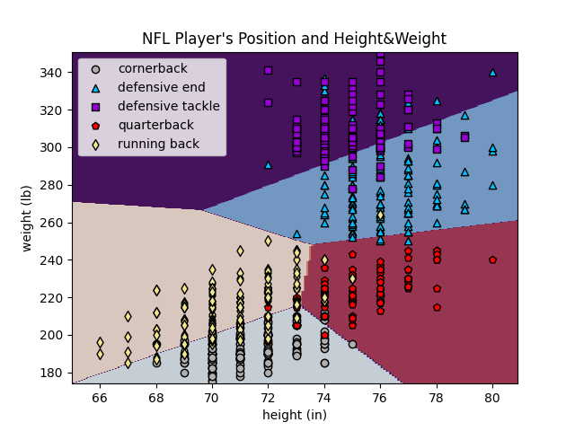

NFL Player.png